# 201.18. Deep_coadd_input_summary table

For the Rubin Science Platform at data.lsst.cloud.  
Data Release: [Data Preview 2](https://dp2.lsst.io/)  
Container Size: Large  
LSST Science Pipelines version: r30.0.11  
Last verified to run: 2026-08-16  
Repository: github.com/lsst/tutorial-notebooks  
DOI: 10.11578/rubin/dc.20250909.20

**Learning objective:** To understand the contents of the `deep_coadd_input_summary` table and how to access it.

**LSST data products:** `deep_coadd_input_summary`, `visit_detector_table`, `skyMap`

**Packages:** `lsst.daf.butler`, `lsst.geom`

**Credit:** Originally developed by the Rubin Community Science team. Please consider acknowledging them if this notebook is used for the preparation of journal articles, software releases, or other notebooks.

**Get Support:** Everyone is encouraged to ask questions or raise issues in the [Support Category](https://community.lsst.org/c/support) of the Rubin Community Forum. Rubin staff will respond to all questions posted there.

## 1. Introduction

The [deep_coadd_input_summary](https://dp2.lsst.io/products/catalogs/deep_coadd_input_summary.html) table provides a list of the visit detector images that contribute to each deep coadd. Note that the `deep_coadd_input_summary` table does not include information about which visit detector images contributed to each deep coadd cell. The `deep_coadd_input_summary` table is available only via the butler.

- butler table name: `deep_coadd_input_summary`
- columns: 7
- rows: 21,235,500

This notebook demonstrates how to access the `deep_coadd_input_summary` table, join it with the `visit_detector_table` to access additional metadata about each visit detector image, and make a plot illustrating the spatial overlap of a coadd patch with the corresponding input visit detector images.

**Related tutorials:** *202.1. Deep coadds* demonstrates how to access information about the visit detector images that contributed to each cell of a deep coadd.

### 1.1. Import packages

Import standard python packages numpy, matplotlib, itertools, and astropy.

From the `lsst` package, import modules for accessing the butler and for geometry from the LSST Science Pipelines (pipelines.lsst.io).

```python
from lsst.daf.butler import Butler
import lsst.geom as geom

from astropy.table import join, unique

import matplotlib.pyplot as plt
import matplotlib.patches as patches

from itertools import cycle

import numpy as np
```

### 1.2. Define parameters and functions

Instantiate a Butler for DP2.

```python
butler = Butler('dp2', collections="dp2")
```

Define the plotting color palette.

```python
plt.style.use('seaborn-v0_8-colorblind')
prop_cycle = plt.rcParams['axes.prop_cycle']
colors = prop_cycle.by_key()['color']
```

## 2. Columns

A schema is not yet published for `deep_coadd_input_summary`. The table contains one row per visit detector image per deep coadd that the visit detector image contributes to. The columns are:

- `tract`: ID number of the top level, 'tract', within the standard LSST skymap
- `patch`: ID number of the second level, 'patch', within the standard LSST skymap
- `visit`: visit ID number
- `detector`: detector ID number
- `weight`: dimensionless weight for the visit detector image when building the deep coadd, which is built using a weighted mean of the relevant visit detector images
- `goodpix`: number of pixels from the visit detector image that overlap the coadd patch
- `band`: name of the band used to take the visit detector image

## 3. Data access

The `deep_coadd_input_summary` table is only available via Butler.

Show that the only dimension for the `deep_coadd_input_summary` table is the skymap.

```python
butler.get_dataset_type('deep_coadd_input_summary')
```

```
DatasetType('deep_coadd_input_summary', {skymap}, ArrowAstropy)
```

```python
butler.get_dataset_type('deep_coadd_input_summary').dimensions.required
```

```
{skymap}
```

### 3.1. Read in the table

There is only one dataset of dataset type `deep_coadd_input_summary`, which is the full table.

```python
dataset_refs = butler.query_datasets("deep_coadd_input_summary")
len(dataset_refs)
```

```
1
```

Read in the `deep_coadd_input_summary` table.

```python
ref = dataset_refs[0]
deep_coadd_input_summary = butler.get(ref)
```

### 3.2. Examine the full table's contents

Sort the table and show the first 10 rows of the table.

```python
deep_coadd_input_summary.sort(['tract', 'patch', 'visit', 'detector'])
deep_coadd_input_summary[0:10]
```

*Table length=10*

| tract int32 | patch int32 | visit int64 | detector int32 | weight float64 | goodpix int32 | band str3 |
| --- | --- | --- | --- | --- | --- | --- |
| 2054 | 0 | 2025090600470 | 45 | 0.0003874042573338706 | 4143707 | i |
| 2054 | 0 | 2025090600470 | 48 | 0.0003874042573338706 | 8423629 | i |
| 2054 | 0 | 2025090600470 | 49 | 0.0003874042573338706 | 664839 | i |
| 2054 | 0 | 2025102400143 | 137 | 0.0013865008561924266 | 12104010 | i |
| 2054 | 0 | 2025102400143 | 140 | 0.0013865008561924266 | 398861 | i |
| 2054 | 0 | 2025102400143 | 144 | 0.0013865008561924266 | 1047704 | i |
| 2054 | 1 | 2025090600470 | 48 | 0.00038877146327636426 | 4557158 | i |
| 2054 | 1 | 2025090600470 | 49 | 0.00038877146327636426 | 8037442 | i |
| 2054 | 1 | 2025090600470 | 51 | 0.00038877146327636426 | 77424 | i |
| 2054 | 1 | 2025090600470 | 52 | 0.00038877146327636426 | 757990 | i |

The number of unique visits in the `deep_coadd_input_summary` table is on the same order as the number of visits in the [DP2 observational dataset](https://dp2.lsst.io/overview/observations.html#visit-images-metadata), but somewhat smaller, for instance due to [quality cuts](https://dp2.lsst.io/processing/coaddition/index.html#input-image-selection) restricting which visits can contribute to the coadds.

```python
len(np.unique(deep_coadd_input_summary['visit']))
```

```
16790
```

The number of unique tracts in the `deep_coadd_input_summary` table is nearly identical to the number of unique tracts within which DP2 deep coadds are available (2,191). The set of deep coadd tracts included in DP2 is a subset of the tracts included in the `deep_coadd_input_summary` table.

```python
len(np.unique(deep_coadd_input_summary['tract']))
```

```
2192
```

Compute the number of unique (tract, patch) pairs in the `deep_coadd_input_summary` table. This number is ~0.2% larger than the number of unique (tract, patch) pairs in the DP2 `CoaddPatches` table. The `CoaddPatches` set of unique (tract, patch) pairs is a subset of the `deep_coadd_input_summary` set of unique (tract, patch) pairs. The (tract, patch) pairs present in `deep_coadd_input_summary` but not included as deep coadds in DP2 generally have very low coverage, with most having only a single overlapping visit detector image.

```python
len(unique(deep_coadd_input_summary, keys=['tract', 'patch']))
```

```
197420
```

Print the list of unique bands in the `deep_coadd_input_summary` table. This matches the list of six LSST filters.

```python
np.unique(deep_coadd_input_summary['band'])
```

<Column name='band' dtype='str3' length=6>

| g |
| --- |
| i |
| r |
| u |
| y |
| z |

The histogram of `goodpix` values is peaked toward relatively low `goodpix` because the sky area within which a detector center could land such that it has a small overlap with the patch footprint is larger than the sky area in which a detector center could land while having a large overlap with the patch footprint. This distribution also serves as an illustration that visits are distributed and oriented randomly with respect to the coadd footprints. The `goodpix` distribution extends up to values of ~14.5 million pixels, which makes sense given that each LSST detector has roughly 4000x4000 = 16 million pixels.

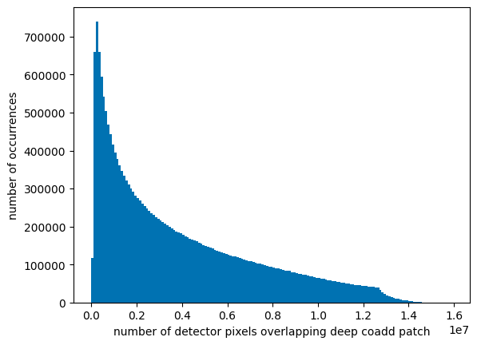

```python
plt.hist(deep_coadd_input_summary['goodpix'], bins=np.arange(0, 16e6, 1e5))
plt.xlabel('number of detector pixels overlapping deep coadd patch')
plt.ylabel('number of occurrences')
plt.show()
```

> Figure 1: Histogram of `goodpix` column values within the full `deep_coadd_input_summary` table. The histogram peak occurs at a `goodpix` value well below the total number of pixels contained in a full visit detector image.

Consider an r-band deep coadd patch in the Extended Chandra Deep Field South (ECDFS). Determine the tract and patch numbers within the LSST skymap.

```python
ra = 53.076
dec = -28.110
band = 'r'

point = geom.SpherePoint(ra * geom.degrees, dec * geom.degrees)

skymap = butler.get("skyMap", skymap="lsst_cells_v2", collections="skymaps")

tract_info = skymap.findTract(point)
tract_id = tract_info.tract_id

patch_info = tract_info.findPatch(point)
patch_index = patch_info.getSequentialIndex()

print(f"Tract: {tract_id}, Patch: {patch_index}")
```

```
Tract: 5063, Patch: 15
```

Downselect to the rows of the `deep_coadd_input_summary` table that represent visit detector images contributing to the r-band deep coadd for this patch.

```python
ecdfs_patch_input_mask = (
    (deep_coadd_input_summary['tract'] == tract_id)
    & (deep_coadd_input_summary['patch'] == patch_index)
    & (deep_coadd_input_summary['band'] == band)
)
ecdfs_patch_input_summary = deep_coadd_input_summary[ecdfs_patch_input_mask]
```

Print the number of r-band visit detector images contributing to this deep coadd patch.

```python
len(ecdfs_patch_input_summary)
```

```
98
```

Clear memory associated with the full `deep_coadd_input_summary` table, as the full table is no longer needed within this notebook.

```python
del deep_coadd_input_summary
```

#### 3.3.1. Join to the `VisitDetector` table

Join the example ECDFS deep coadd patch's input table to the `VisitDetector` table in order to access additional metadata, such as detector (RA, Dec) coordinates, for each relevant visit detector image. Access the `VisitDetector` table via the butler.

```python
dataset_refs = butler.query_datasets("visit_detector_table")
ref = dataset_refs[0]
visit_detector_table = butler.get(ref)
```

Join the example ECDFS deep coadd patch's input table to the VisitDetector table.

```python
ecdfs_patch_input_summary.rename_column('visit', 'visitId')
ecdfs_patch_input_summary.rename_column('detector', 'detectorId')

joined_table = join(ecdfs_patch_input_summary, visit_detector_table,
                    keys=['visitId', 'detectorId'], join_type='left')
```

Clear memory associated with the full `visit_detector_table`, as the full table is no longer needed within this notebook.

```python
del visit_detector_table
```

#### 3.3.2. Plot overlap between deep coadd and input detectors

Create a rectangle representing the sky footprint of the chosen ECDFS deep coadd patch.

```python
tract_info = skymap[tract_id]
patch_info = tract_info.getPatchInfo(patch_index)

wcs = patch_info.wcs
patch_box = patch_info.outer_bbox

pixel_corners = patch_box.getCorners()

sky_corners = [wcs.pixelToSky(geom.Point2D(pixel_pos)) for pixel_pos in pixel_corners]

ra_patch_corners = [sky_pos.getRa().asDegrees() for sky_pos in sky_corners]
dec_patch_corners = [sky_pos.getDec().asDegrees() for sky_pos in sky_corners]

vertices = list(zip(ra_patch_corners, dec_patch_corners))

patch_rect = patches.Polygon(
    vertices,
    closed=True,
    edgecolor='gray',
    facecolor='gray',
    alpha=0.3,
    linewidth=2,
    label='coadd patch footprint'
)
```

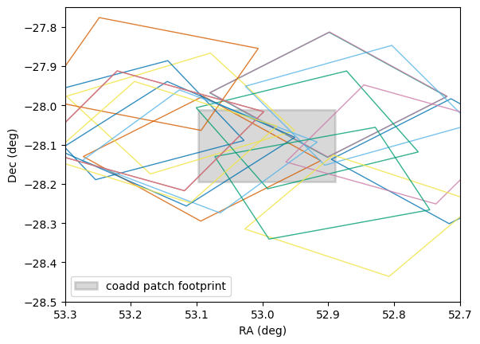

```python
plt.figure()

ax = plt.gca()

ax.add_patch(patch_rect)

input_detectors_to_plot = joined_table[::6]

color_iterator = cycle(colors)

for row in input_detectors_to_plot:
    vertices_detector = list(zip([row['llcra'], row['ulcra'], row['urcra'], row['lrcra']],
                                 [row['llcdec'], row['ulcdec'], row['urcdec'], row['lrcdec']]))
    detector_outline = patches.Polygon(
        vertices_detector,
        closed=True,
        edgecolor=next(color_iterator),
        facecolor='none',
        alpha=0.8,
        linewidth=1,
    )

    ax.add_patch(detector_outline)

plt.legend()
plt.xlim((53.3, 52.7))
plt.ylim((-28.5, -27.75))
plt.xlabel('RA (deg)')
plt.ylabel('Dec (deg)')

plt.show()
```